# SLR_jml_pdd_miskin_nilai_ipm

## Regresi Linear Sederhana

**Oleh *Galih Suwarmo***

### Prediksi jumlah angka kemiskinan berdasarkan nilai IPM

IPM menjelaskan bagaimana penduduk dapat mengakses hasil pembangunan dalam memperoleh pendapatan, kesehatan, pendidikan, dan sebagainya.

Kali ini kita akan mencari persamaan Regresi Linear Sederhana (*Simple Linear Regression*) dari data di kota Semarang pada tahun 2012 hingga 2019 dengan angka kemiskinan sebagai variabel dependen/target(y) dan nilai IPM sebagai variabel dependen/prediktor(x). Silahkan menggunakan data yang sama atau menggunakan data minuman yang sudah disiapkan [disini](https://github.com/fivethirtyeight/data/tree/master/alcohol-consumption).

Langkah pertama import library yang diperlukan

```python
import pandas as pd
import numpy
import matplotlib.pyplot as plt
import matplotlib as mpl
```

Dibawah ini merupakan sample data jumlah penduduk miskin dan nilai IPM di kota Semarang pada tahun 2012 sampai 2019

```python
dataset = pd.DataFrame([
    [83346,78.04],
    [86734,78.68],
    [84640,79.24],
    [84270,80.22],
    [83590,81.19],
    [80860,82.01],
    [73650,82.72],
    [71969,83.19]
])
dataset.columns = ['jml_pdd_miskin', 'nilai_ipm']
dataset
```

|  | jml_pdd_miskin | nilai_ipm |
| --- | --- | --- |
| 0 | 83346 | 78.04 |
| 1 | 86734 | 78.68 |
| 2 | 84640 | 79.24 |
| 3 | 84270 | 80.22 |
| 4 | 83590 | 81.19 |
| 5 | 80860 | 82.01 |
| 6 | 73650 | 82.72 |
| 7 | 71969 | 83.19 |

Untuk melihat linearitas antara predictor dan target import library `seaborn` dan gunakan fungsi `pairplot()`

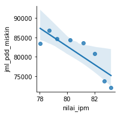

```python
import seaborn as sns
sns.pairplot(dataset,
                x_vars=['nilai_ipm'],
                y_vars=['jml_pdd_miskin'],
                kind='reg'
            )
```

berdasarkan plot diatas antara target dan predictor menunjukan korelasi yang cukup baik

### Pemodelan Regresi Linear Sederhana

Buat objek LinearRegression kemudian tentukan x dan y

```python
from sklearn.linear_model import LinearRegression
lm = LinearRegression()
x=dataset[['nilai_ipm']]
y=dataset[['jml_pdd_miskin']]
```

Untuk membuat model gunakan fungsi `fit()` untuk objek yang sudah dibuat

```python
model=lm.fit(x,y)
model
```

```
LinearRegression(copy_X=True, fit_intercept=True, n_jobs=None, normalize=False)
```

Persamaan Regrei Linear Sederhana : `y = b0 + b1x`

```python
lm.intercept_ #b0
```

```
array([271999.75079331])
```

```python
lm.coef_ #b1
```

```
array([[-2366.2833863]])
```

Persamaan Regresi Linear adalah : **`jml_pdd_miskin = 272000 + (-2366) * nilai_ipm`**

Evaluasi model dengan R kuadrat. Nilai R kuadrat berada antara 0 sampai 1. Sebuah model dianggap cukup baik jika nilai R kuadrat mendekati 1. Gunakan fungsi `score()`

```python
lm.score(x,y)
```

```
0.7048666038453966
```

```python
import os

os.system('jupyter nbconvert --to html SLRjml_pdd_miskin_nilai_ipm.ipynb')
```

```
65280
```